# Chapter 13 - Correlations and clusters

Bodo Winter

8/24/2018

## Introduction

This is the analysis for Chapter 13. Part I starts by looking at correlations between the senses. The PCA from Lynott and Connell (2009) is repeated here. Part II performs a cluster analysis to look at smaller subgroupings within the raw scores.

We begin by loading in the data and libraries.

```r
## Libraries:

library(png)        # for plotting sensory modality images
library(GISTools)   # for adding alpha to hex values
library(plotrix)    # for plotting circles
library(mclust) # for cluster analysis
library(tidyverse)
library(stringr)

## Load data:

lyn <- read_csv('../raw-data/modality_lynott_connell_2009.csv')
noun <- read_csv('../raw-data/modality_lynott_connell_2013.csv')
```

Some more preprocessing:

```r
## Vector of modality names:

mymods <- c('Visual', 'Haptic', 'Auditory',
            'Gustatory', 'Olfactory')

## Vector of column names:

mymods_names <- str_c(mymods, 'StrengthMean')

## Load plotting functions:

source('../functions/emptyplot.R')
```

We will use the image data (from freepix.com). So let’s load in images and specify the color values.

```r
## Load in images:

setwd('/Users/winterb/Books/words_of_sense/analysis/figures/')
s1 <- readPNG('../figures/sight.png')
s2 <- readPNG('../figures/touch.png')
s3 <- readPNG('../figures/sound.png')
s4 <- readPNG('../figures/taste.png')
s5 <- readPNG('../figures/smell.png')

## Define vector of names:

sense_names <- str_c('s', 1:5)

## Define colors:

mycols <- c('#f37058', '#f79038', '#efbe1b',
            '#425fac', '#30b77d')
```

## Principal Components Analysis (PCA)

We look at correlations between the senses with a simple PCA. For this, we extract a matrix of the sensory ratings and standardize this matrix.

```r
## Get matrix of adjectives:

adjm <- as.matrix(lyn[ , mymods_names])
rownames(adjm) <- lyn$Word

## Standardize matrix:

adjm <- apply(adjm, 2,
    FUN = function(x) (x - mean(x)) / sd(x))
```

Next we compute the PCA.

```r
## Get PCAs:

adj_pca <- prcomp(adjm, center = TRUE, scale = TRUE)
    # prcomp preferred over princomp because SVD has more numerical precision

## Inspect:

summary(adj_pca)
```

```
## Importance of components:
##                           PC1    PC2    PC3     PC4    PC5
## Standard deviation     1.4514 1.2772 0.8200 0.62519 0.4461
## Proportion of Variance 0.4213 0.3262 0.1345 0.07817 0.0398
## Cumulative Proportion  0.4213 0.7475 0.8820 0.96020 1.0000
```

```r
## Inspect loadings:

round(adj_pca$rotation, 1)
```

```
##                        PC1  PC2  PC3 PC4  PC5
## VisualStrengthMean     0.3 -0.6 -0.5 0.6  0.0
## HapticStrengthMean     0.2 -0.5  0.8 0.0 -0.2
## AuditoryStrengthMean   0.3  0.6  0.3 0.7 -0.1
## GustatoryStrengthMean -0.6 -0.1  0.2 0.4  0.7
## OlfactoryStrengthMean -0.6 -0.1  0.0 0.2 -0.7
```

To explore this structure further, we plot the first two dimensions into a 2D plane.

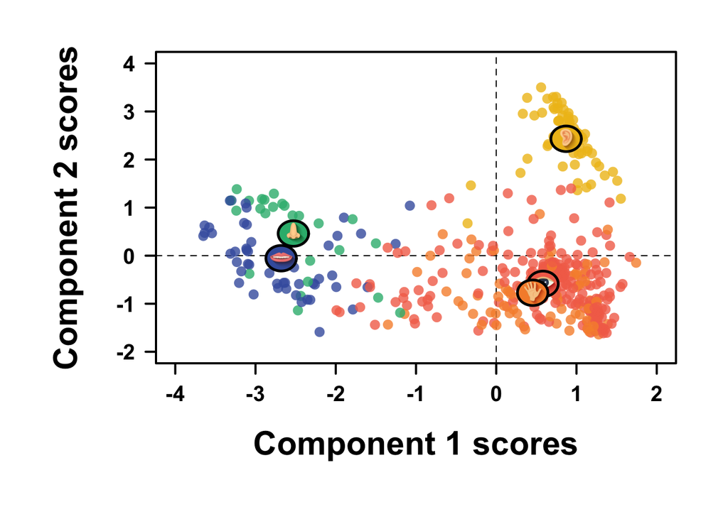

```r
## Get first two scores for plotting:

adj2 <- adj_pca$x[, 1:2]

## Define factor order for correct color plotting:

myfacs <- factor(lyn$DominantModality,
    levels = c('Visual', 'Haptic', 'Auditory', 'Gustatory', 'Olfactory'))

## Get means per modality for plotting sense symbols:

adj2_plot <- as_tibble(adj2)
adj2_plot$Modality <- lyn$DominantModality
sense_pos <- adj2_plot %>% group_by(Modality) %>%
    summarize(C1 = mean(PC1),
        C2 = mean(PC2))
sense_pos$Modality <- c('s3', 's4', 's2', 's5', 's1')

## Plot the first two dimensions:

quartz('', 9, 7)
par(mai = c(1.5, 1.5, 0.5, 0.5))
emptyplot(xlim = c(-4, 2),
          ylim = c(-2, 4), AB = '')
abline(h = 0, lty = 2); abline(v = 0, lty = 2)
axis(side = 1,
     at = seq(-4, 2, 1), lwd.ticks = 2,
     lwd = 2, font = 2, cex.axis = 1.25)
mtext(side = 1, line = 3.6,
      text = 'Component 1 scores', cex = 1.9, font = 2)
axis(side = 2,
     at = seq(-2, 4, 1), lwd.ticks = 2,
     lwd = 2, font = 2, cex.axis = 1.25, las = 2)
mtext(side = 2, line = 3.6,
      text = 'Component 2 scores', cex = 1.9, font = 2)
points(adj2_plot[, 1:2], pch = 16, cex = 1.3,
       col = add.alpha(mycols[as.numeric(myfacs)], 0.8))
for (i in c(5, 3, 2, 4, 1)) {
  rasterImage(get(pull(sense_pos[i, 1])),
              xleft = sense_pos[i, ]$C1 - 0.19,
              xright = sense_pos[i, ]$C1 + 0.19,
              ybottom = sense_pos[i, ]$C2 - 0.28,
              ytop = sense_pos[i, ]$C2 + 0.28, xpd = NA)
  draw.circle(x = sense_pos[i, ]$C1,
              y = sense_pos[i, ]$C2, radius = 0.19, lwd = 2.5)
    }
```

Next, we create a variable coordinate plot, with code from:

http://www.sthda.com/english/wiki/principal-component-analysis-in-r-prcomp-vs-princomp-r-software-and-data-mining

[figure not shown]

```r
## Helper function: for correlation between variables and components:
var_cor_func <- function(var.loadings, comp.sdev) {
  var.loadings * comp.sdev
  }

## Extract variable correlation/coordinates:

loadings <- adj_pca$rotation
sdev <- adj_pca$sdev
var.coord <- var.cor <- t(apply(loadings, 1, var_cor_func, sdev))

## Change names:

rownames(var.coord) <- c('Sight', 'Sound',
                         'Touch', 'Taste', 'Smell')

## Re-order to reflect modality order:

var.coord <- var.coord[c(1, 3, 2, 4, 5), ]

## Plot the correlation circle:

a <- seq(0, 2*pi, length = 100)
quartz('', 9, 6)
par(mai = c(1.5, 1.75, 0.5, 1))
plot(cos(a), sin(a), type = 'l', col = 'gray',  # plots circle
     xlim = c(-1.2, 1.2), ylim = c(-1.2, 1.2),
     bty = 'n', xaxt = 'n', yaxt = 'n',
     xlab = '', ylab = '')
axis(side = 1, at = seq(-1, 1, 0.5), font = 2,
     lwd = 2, lwd.ticks = 2, cex.axis = 1.25)
axis(side = 2, at = seq(-1, 1, 0.5), font = 2,
     lwd = 2, lwd.ticks = 2, cex.axis = 1.25, las = 2)
mtext(side = 1, line = 4.25, font = 2, cex = 2,
      text = 'Principal Component 1')
mtext(side = 2, line = 4.25, font = 2, cex = 2,
      text = 'Principal Component 2')
abline(h = 0, v = 0, lty = 2)
# Add active variables
arrows(0, 0, var.coord[, 1], var.coord[, 2],
       length = 0.1, angle = 15, code = 2, col = mycols,
       lwd = 2)
# Add labels:
var.coord_adj <- var.coord[, 1:2]
var.coord_adj[, 1] <- var.coord_adj[, 1] +
  c(0.23, 0.12, 0.06, -0.025, -0.025)
var.coord_adj[, 2] <- var.coord_adj[, 2] +
  c(-0.1, +0.08, -0.09, -0.045, +0.045)
text(var.coord_adj, labels = rownames(var.coord),
     adj = 1, col = mycols, font = 2, cex = 1.5)
box(lwd = 2)
```

## Cluster analysis on PCA scores

For all cluster analysis, originally version 5.2 was used, which used a different algorithm. Check description of version 5.4 on this page:

https://github.com/cran/mclust/blob/master/inst/NEWS

```r
mclust.options(hcUse = "VARS")
```

```r
## Gaussian mixture models:

xclust <- Mclust(adj2, G = 1:15)
summary(xclust, parameters = TRUE)
```

```
## ----------------------------------------------------
## Gaussian finite mixture model fitted by EM algorithm
## ----------------------------------------------------
##
## Mclust VVE (ellipsoidal, equal orientation) model with 8 components:
##
##  log.likelihood   n df       BIC       ICL
##       -976.5007 423 40 -2194.896 -2311.872
##
## Clustering table:
##   1   2   3   4   5   6   7   8
##  34  73 132  40  57  44  23  20
##
## Mixing probabilities:
##          1          2          3          4          5          6
## 0.07161481 0.16784089 0.32010494 0.11216946 0.12572128 0.09799988
##          7          8
## 0.05858283 0.04596591
##
## Means:
##           [,1]       [,2]       [,3]       [,4]      [,5]      [,6]
## PC1  0.7455230 -2.7508693  0.6707015 -0.4637739  1.216135 0.9383325
## PC2 -0.2774738  0.1009381 -0.6487624  0.3155435 -1.279863 2.6699519
##          [,7]      [,8]
## PC1 0.8988587 -1.128313
## PC2 2.0730383 -1.022193
##
## Variances:
## [,,1]
##              PC1          PC2
## PC1  0.007015301 -0.007641615
## PC2 -0.007641615  0.020899948
## [,,2]
##            PC1        PC2
## PC1  0.2377788 -0.1790527
## PC2 -0.1790527  0.5631137
## [,,3]
##            PC1        PC2
## PC1 0.27732736 0.04817013
## PC2 0.04817013 0.18980328
## [,,4]
##           PC1       PC2
## PC1 0.9668616 0.2672742
## PC2 0.2672742 0.4812302
## [,,5]
##             PC1         PC2
## PC1  0.01780138 -0.01519253
## PC2 -0.01519253  0.04540589
## [,,6]
##             PC1         PC2
## PC1  0.03551191 -0.07374635
## PC2 -0.07374635  0.16950740
## [,,7]
##            PC1        PC2
## PC1  0.1084154 -0.1672355
## PC2 -0.1672355  0.4122786
## [,,8]
##            PC1        PC2
## PC1 0.10717025 0.01797936
## PC2 0.01797936 0.07450214
```

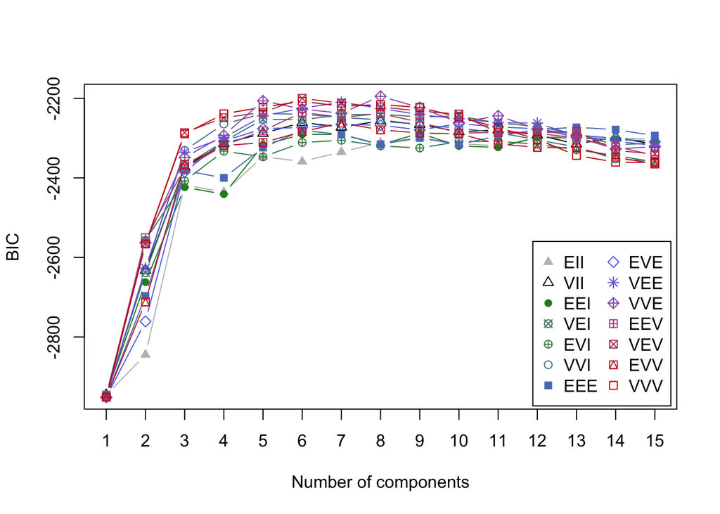

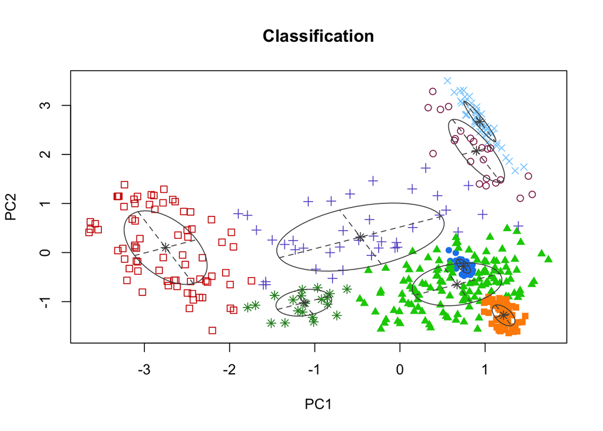

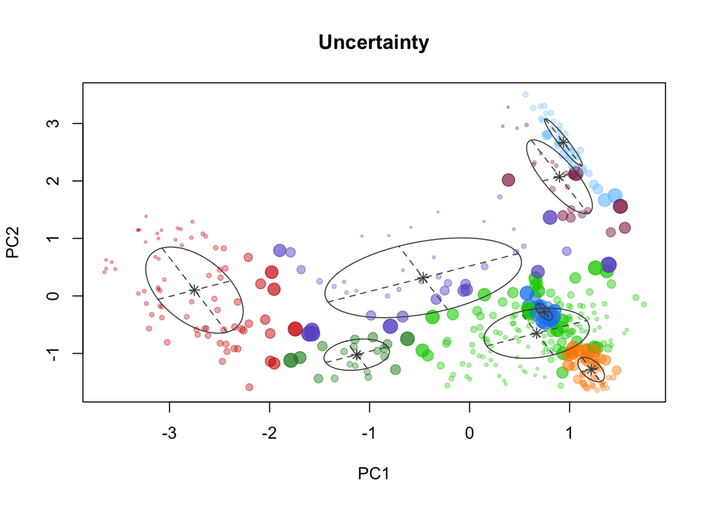

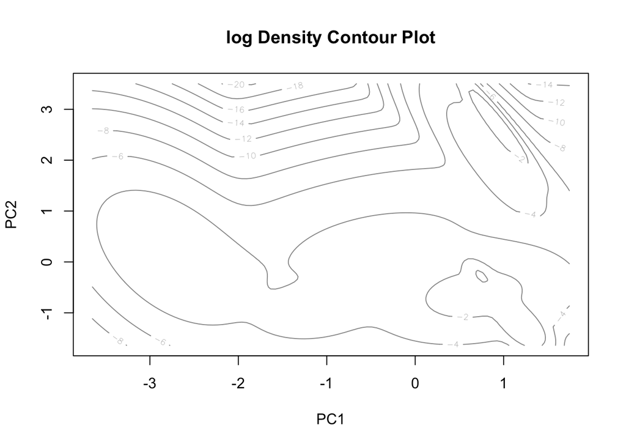

```r
## Plot BIC etc.:

plot(xclust)    # suggests BIC elbow for 3 components (heuristic)
```

```r
## What is the optimal number of mixture components, maximizing BIC?

xclust$G    # 8
```

```
## [1] 8
```

```r
## Enforce a three-cluster solution:

xclust3 <- Mclust(adj2, G = 1:3)
xclust3$G
```

```
## [1] 3
```

```r
## Get three-cluster classifications and uncertainties:

lyn$Classes3 <- xclust3$classification
lyn$Uncertainty3 <- xclust3$uncertainty

## Tabulate:

with(filter(lyn, Uncertainty3 < 0.06),
     table(Classes3, DominantModality))
```

```
##         DominantModality
## Classes3 Auditory Gustatory Haptic Olfactory Visual
##        1        0         0     11         0     36
##        2        2        54     29        26     40
##        3       65         0      0         0      3
```

```r
## Check words:

filter(lyn, Uncertainty3 < 0.06, Classes3 == 1) %>%
  arrange(Uncertainty3) %>% pull(Word)
```

```
##  [1] "broad"       "itchy"       "elastic"     "ticklish"    "spotted"
##  [6] "weightless"  "wispy"       "patterned"   "heavy"       "rotund"
## [11] "colossal"    "striped"     "dazzling"    "scrawny"     "sore"
## [16] "glittery"    "shiny"       "craggy"      "bright"      "brunette"
## [21] "speckled"    "bristly"     "petite"      "yellow"      "blue"
## [26] "sunny"       "contoured"   "shimmering"  "sparkly"     "transparent"
## [31] "tapering"    "khaki"       "forked"      "spilling"    "translucent"
## [36] "hard"        "bumpy"       "sturdy"      "compact"     "purple"
## [41] "loose"       "puny"        "shallow"     "checkered"   "brittle"
## [46] "crooked"     "miniature"
```

```r
filter(lyn, Uncertainty3 < 0.06, Classes3 == 2) %>%
  arrange(Uncertainty3) %>% pull(Word)
```

```
##   [1] "acidic"      "acrid"       "alcoholic"   "antiseptic"  "aromatic"
##   [6] "barbecued"   "beery"       "biscuity"    "bitter"      "bland"
##  [11] "briny"       "burning"     "burnt"       "buttery"     "caramelized"
##  [16] "charred"     "cheesy"      "chocolatey"  "citrusy"     "cloying"
##  [21] "coconutty"   "creamy"      "delicious"   "eggy"        "fatty"
##  [26] "fishy"       "flavorsome"  "fragrant"    "fresh"       "fruity"
##  [31] "garlicky"    "greasy"      "herby"       "honeyed"     "hot"
##  [36] "jammy"       "juicy"       "lemony"      "lush"        "malty"
##  [41] "meaty"       "mild"        "minty"       "moldy"       "mushroomy"
##  [46] "musky"       "musty"       "noxious"     "nutty"       "odorous"
##  [51] "oniony"      "orangey"     "palatable"   "peachy"      "peppery"
##  [56] "perfumed"    "pungent"     "putrid"      "rancid"      "reeking"
##  [61] "ripe"        "roasted"     "roasting"    "rotten"      "salty"
##  [66] "savory"      "scented"     "scentless"   "smelly"      "smoky"
##  [71] "sour"        "spicy"       "stale"       "stenchy"     "stinky"
```

[output cut: 16 more lines]

```r
filter(lyn, Uncertainty3 < 0.06, Classes3 == 3) %>%
  arrange(Uncertainty3) %>% pull(Word)
```

```
##  [1] "echoing"       "deafening"     "audible"       "mute"
##  [5] "sonorous"      "beeping"       "noisy"         "bleeping"
##  [9] "loud"          "shrill"        "silent"        "quiet"
## [13] "mumbling"      "melodious"     "whistling"     "cooing"
## [17] "squealing"     "blaring"       "squeaking"     "hushed"
## [21] "murmuring"     "soundless"     "screeching"    "groaning"
## [25] "whining"       "hissing"       "meowing"       "muffled"
## [29] "whispering"    "shrieking"     "muttering"     "purring"
## [33] "screaming"     "howling"       "wailing"       "booming"
## [37] "moaning"       "buzzing"       "creaking"      "husky"
## [41] "resounding"    "growling"      "snorting"      "whimpering"
## [45] "tinkling"      "rhythmic"      "jingling"      "barking"
## [49] "raucous"       "thunderous"    "warbling"      "hoarse"
## [53] "snarling"      "banging"       "rumbling"      "gurgling"
## [57] "giggling"      "thudding"      "laughing"      "rustling"
## [61] "reverberating" "thumping"      "raspy"         "popping"
## [65] "stormy"        "crying"        "crashing"      "wizened"
```

```r
## Extract 8 cluster classifications and uncertainties:

lyn$Classes <- xclust$classification
lyn$Uncertainty <- xclust$uncertainty

## Tabulate:

with(filter(lyn, Uncertainty < 0.15),
     table(Classes, DominantModality))
```

```
##        DominantModality
## Classes Auditory Gustatory Haptic Olfactory Visual
##       1        0         0      2         0     10
##       2        0        44      0        21      0
##       3        0         0     37         0     64
##       4        3         3      4         1     12
##       5        0         0      7         0     34
##       6       36         0      0         0      0
##       7       16         0      0         0      0
##       8        0         0      2         1      8
```

The three-cluster solution appears to converge on the following three clusters. A sound cluster. A highly multisensory cluster that includes taste and smell. And a touch/sight cluster that excludes taste and smell.

Check the words that emerge from this cluster solution.

```r
## Check words:

filter(lyn, Classes == 1) %>%
  arrange(Uncertainty) %>% pull(Word)
```

```
##  [1] "glowing"     "shadowy"     "gray"        "black"       "stinging"
##  [6] "bursting"    "blonde"      "beige"       "dappled"     "white"
## [11] "feverish"    "crimson"     "glamorous"   "purple"      "shimmering"
## [16] "yellow"      "tapering"    "checkered"   "pale"        "transparent"
## [21] "brunette"    "downy"       "reddish"     "bright"      "translucent"
## [26] "khaki"       "striped"     "abrasive"    "cloudy"      "dazzling"
## [31] "elegant"     "gold"        "foggy"       "dark"
```

```r
filter(lyn, Classes == 2) %>%
  arrange(Uncertainty) %>% pull(Word)
```

```
##  [1] "perfumed"    "tangy"       "fragrant"    "bitter"      "aromatic"
##  [6] "tasteless"   "scented"     "sour"        "spicy"       "minty"
## [11] "scentless"   "sweet"       "vinegary"    "flavorsome"  "odorous"
## [16] "reeking"     "bland"       "garlicky"    "whiffy"      "pungent"
## [21] "stinky"      "alcoholic"   "savory"      "tasty"       "peppery"
## [26] "citrusy"     "cheesy"      "smelly"      "acrid"       "herby"
## [31] "lemony"      "eggy"        "fruity"      "delicious"   "fishy"
## [36] "stenchy"     "putrid"      "palatable"   "oniony"      "malty"
## [41] "beery"       "unpalatable" "musky"       "acidic"      "caramelized"
## [46] "barbecued"   "buttery"     "honeyed"     "coconutty"   "salty"
## [51] "chocolatey"  "meaty"       "nutty"       "fresh"       "burnt"
## [56] "stale"       "orangey"     "smoky"       "mushroomy"   "rancid"
## [61] "biscuity"    "ripe"        "roasted"     "jammy"       "antiseptic"
## [66] "juicy"       "peachy"      "tart"        "tangerine"   "rotten"
## [71] "musty"       "cloying"     "roasting"
```

```r
filter(lyn, Classes == 3) %>%
    arrange(Uncertainty) %>% pull(Word)
```

```
##   [1] "foamy"      "fluffy"     "smooth"     "icy"        "polished"
##   [6] "dusty"      "lumpy"      "fat"        "breakable"  "freezing"
##  [11] "plastic"    "broken"     "frosty"     "deep"       "gooey"
##  [16] "crinkled"   "rippled"    "flaky"      "wet"        "slimy"
##  [21] "swinging"   "spotless"   "slick"      "motionless" "ugly"
##  [26] "sodden"     "brittle"    "leathery"   "sore"       "muddy"
##  [31] "grubby"     "colossal"   "fleshy"     "rippling"   "rough"
##  [36] "adhesive"   "rusty"      "boiling"    "branching"  "soggy"
##  [41] "metal"      "handsome"   "gritty"     "dry"        "slippery"
##  [46] "shallow"    "tough"      "empty"      "chilly"     "filthy"
##  [51] "glittery"   "bloody"     "sticky"     "low"        "painful"
##  [56] "portly"     "bouncy"     "misty"      "grainy"     "green"
##  [61] "spilling"   "fuzzy"      "waxy"       "grassy"     "melted"
##  [66] "sparkly"    "heavy"      "mushy"      "weightless" "pulsing"
##  [71] "clammy"     "absorbent"  "scaly"      "mottled"    "bronze"
##  [76] "globular"   "soft"       "gigantic"   "hollow"     "light"
##  [81] "itchy"      "colorful"   "cool"       "broad"      "flickering"
##  [86] "high"       "ticklish"   "amber"      "craggy"     "blue"
##  [91] "damp"       "slushy"     "silver"     "elastic"    "open"
##  [96] "cold"       "dead"       "tarry"      "glistening" "rotund"
## [101] "falling"    "puffy"      "alive"      "blotchy"    "puny"
## [106] "murky"      "radiant"    "brown"      "cute"       "speckled"
## [111] "patterned"  "rubbery"    "hazy"       "weak"       "gleaming"
## [116] "sharp"      "dim"        "wispy"      "sunny"      "steep"
## [121] "drab"       "spotted"    "sheer"      "aching"     "lithe"
## [126] "moist"      "clear"      "crowded"    "pink"       "tender"
## [131] "red"        "swift"
```

```r
filter(lyn, Classes == 4) %>%
    arrange(Uncertainty) %>% pull(Word)
```

```
##  [1] "crunching"  "faint"      "insipid"    "astringent" "mellow"
##  [6] "lilting"    "brackish"   "harsh"      "stagnant"   "chewy"
## [11] "strange"    "medicinal"  "dank"       "lukewarm"   "crackling"
## [16] "clamorous"  "brilliant"  "tepid"      "happy"      "fetid"
## [21] "dull"       "muggy"      "briny"      "breezy"     "humid"
## [26] "gamy"       "noxious"    "vivid"      "crisp"      "beautiful"
## [31] "immense"    "tingly"     "mild"       "searing"    "wizened"
## [36] "charred"    "plain"      "fatty"      "vegetal"    "scratchy"
```

```r
filter(lyn, Classes == 5) %>%
    arrange(Uncertainty) %>% pull(Word)
```

```
##  [1] "straight"    "conical"     "skinny"      "bent"        "rectangular"
##  [6] "circular"    "round"       "square"      "curved"      "jagged"
## [11] "blunt"       "wide"        "hairy"       "woolly"      "curly"
## [16] "creased"     "angular"     "shaggy"      "small"       "triangular"
## [21] "flat"        "short"       "big"         "silky"       "floppy"
## [26] "large"       "chubby"      "tall"        "bulky"       "spiky"
## [31] "thorny"      "little"      "oval"        "narrow"      "miniature"
## [36] "crooked"     "loose"       "sturdy"      "tiny"        "glossy"
## [41] "compact"     "contoured"   "long"        "uneven"      "prickly"
## [46] "huge"        "bumpy"       "enormous"    "hard"        "solid"
## [51] "shiny"       "petite"      "bristly"     "forked"      "wiry"
## [56] "tight"       "scrawny"
```

```r
filter(lyn, Classes == 6) %>%
    arrange(Uncertainty) %>% pull(Word)
```

```
##  [1] "whistling"  "bleeping"   "beeping"    "squealing"  "mumbling"
##  [6] "audible"    "quiet"      "noisy"      "whining"    "murmuring"
## [11] "shrieking"  "purring"    "screeching" "howling"    "wailing"
## [16] "muttering"  "cooing"     "silent"     "loud"       "deafening"
## [21] "echoing"    "moaning"    "shrill"     "whispering" "sonorous"
## [26] "mute"       "groaning"   "whimpering" "hissing"    "creaking"
## [31] "screaming"  "jingling"   "buzzing"    "rhythmic"   "meowing"
## [36] "squeaking"  "hushed"     "snarling"   "booming"    "soundless"
## [41] "growling"   "banging"    "thudding"   "giggling"
```

```r
filter(lyn, Classes == 7) %>%
    arrange(Uncertainty) %>% pull(Word)
```

```
##  [1] "melodious"     "muffled"       "husky"         "resounding"
##  [5] "blaring"       "snorting"      "tinkling"      "warbling"
##  [9] "hoarse"        "raucous"       "rumbling"      "gurgling"
## [13] "rustling"      "reverberating" "thumping"      "thunderous"
## [17] "popping"       "crashing"      "stormy"        "crying"
## [21] "raspy"         "barking"       "laughing"
```

```r
filter(lyn, Classes == 8) %>%
    arrange(Uncertainty) %>% pull(Word)
```

```
##  [1] "hot"       "sweaty"    "floral"    "oily"      "lush"
##  [6] "clean"     "greasy"    "orange"    "flowery"   "soapy"
## [11] "earthy"    "strong"    "unripe"    "gorgeous"  "burning"
## [16] "grotesque" "dirty"     "moldy"     "warm"      "creamy"
```